# Lecture 8: Logistic Regression

Linear regression with `lm()` models a continuous response. Field-goal success is binary: an attempt is made or missed. Logistic regression fits probabilities for a binary response.

## Binary Outcomes and Logistic Regression

A linear regression can produce fitted values below 0 or above 1, which cannot be probabilities. Logistic regression fits a curve that stays between 0 and 1.

The files `nfl_fg_train.csv` and `nfl_fg_test.csv` contain NFL field-goal attempts from 2005 through 2015. The response `success` equals 1 for a made field goal and 0 for a miss. Fit both candidate models with the training file, then use the testing file to select between them.

```r
fg_train <- read_csv("data/nfl_fg_train.csv", show_col_types = FALSE)
```

## Logistic Regression with `glm()`

Fit a logistic regression with `glm()`. The formula still has the form `response ~ predictor`. The argument `family = binomial` tells R that the response is binary.

```r
logit_distance <- glm(
  success ~ distance,
  family = binomial,
  data = fg_train
)
```

Create a grid of distances and predict at every value. For logistic regression, `type = "response"` returns probabilities rather than the model’s internal log-odds scale.

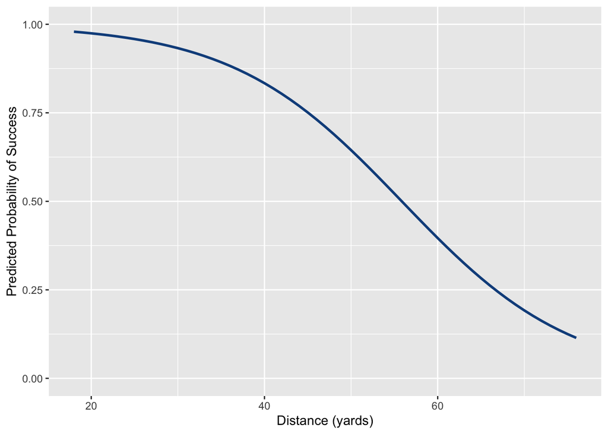

```r
distance_grid <- tibble(
  distance = seq(min(fg_train$distance), max(fg_train$distance), by = 1)
) %>%
  mutate(
    predicted_probability = predict(
      logit_distance,
      newdata = .,
      type = "response"
    )
  )

ggplot(distance_grid, aes(x = distance, y = predicted_probability)) +
  geom_line(linewidth = 1, color = "dodgerblue4") +
  scale_y_continuous(limits = c(0, 1)) +
  labs(x = "Distance (yards)", y = "Predicted Probability of Success")
```

Short field goals have high fitted probabilities, and the probability decreases smoothly as distance increases.

## Multiple Logistic Regression

The distance-only model gives every kicker the same probability from a given distance. Add `kicker` to account for systematic differences among kickers.

```r
logit_dist_kicker <- glm(
  success ~ distance + kicker,
  family = binomial,
  data = fg_train
)
```

`distance + kicker` tells R to use both predictors. Create every combination of distance and three kickers, then predict for each row.

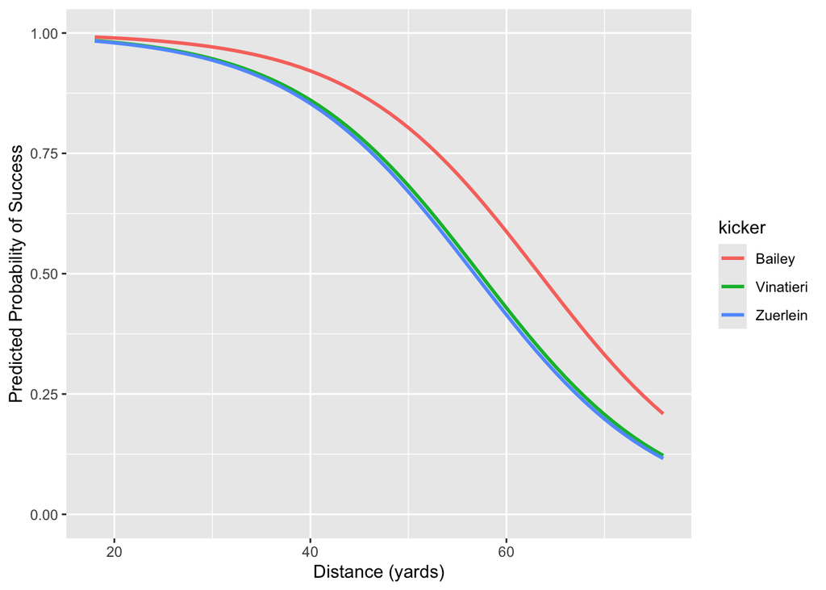

```r
dist_kicker_grid <- expand_grid(
  distance = seq(min(fg_train$distance), max(fg_train$distance), by = 1),
  kicker = c("Bailey", "Vinatieri", "Zuerlein")
) %>%
  mutate(
    predicted_probability = predict(
      logit_dist_kicker,
      newdata = .,
      type = "response"
    )
  )

ggplot(
  dist_kicker_grid,
  aes(x = distance, y = predicted_probability, color = kicker)
) +
  geom_line(linewidth = 1) +
  scale_y_continuous(limits = c(0, 1)) +
  labs(x = "Distance (yards)", y = "Predicted Probability of Success")
```

At the same distance, the model assigns Dan Bailey a higher fitted success probability than Greg Zuerlein or Adam Vinatieri.

## Training Fit

A baseline prediction assigns every attempt the overall success rate from the training data. Add the baseline and both logistic predictions to the training rows.

```r
overall_success <- mean(fg_train$success)

fg_train <- fg_train %>%
  mutate(
    overall = overall_success,
    distance_only = predict(
      logit_distance,
      newdata = .,
      type = "response"
    ),
    distance_kicker = predict(
      logit_dist_kicker,
      newdata = .,
      type = "response"
    )
  )
```

Calculate RMSE using the observed 0/1 outcome and each predicted probability. Lower RMSE means that the predicted probabilities are closer to the observed outcomes.

```r
training_scores <- fg_train %>%
  summarize(
    overall = sqrt(mean((success - overall)^2)),
    distance_only = sqrt(mean((success - distance_only)^2)),
    distance_kicker = sqrt(mean((success - distance_kicker)^2))
  ) %>%
  pivot_longer(everything(), names_to = "model", values_to = "rmse") %>%
  mutate(sample = "Training")

training_scores
```

```
## # A tibble: 3 × 3
##   model              rmse sample
##   <chr>             <dbl> <chr>
## 1 overall         0.37453 Training
## 2 distance_only   0.35121 Training
## 3 distance_kicker 0.34802 Training
```

The distance-plus-kicker model has the lowest training RMSE. The testing data determine whether the added predictor improves predictions for held-out attempts.

## Selecting a Logistic Model

Load the testing data after both logistic models have been fit. Apply the baseline and both models without refitting.

```r
fg_test <- read_csv("data/nfl_fg_test.csv", show_col_types = FALSE) %>%
  mutate(
    overall = overall_success,
    distance_only = predict(
      logit_distance,
      newdata = .,
      type = "response"
    ),
    distance_kicker = predict(
      logit_dist_kicker,
      newdata = .,
      type = "response"
    )
  )
```

```r
testing_scores <- fg_test %>%
  summarize(
    overall = sqrt(mean((success - overall)^2)),
    distance_only = sqrt(mean((success - distance_only)^2)),
    distance_kicker = sqrt(mean((success - distance_kicker)^2))
  ) %>%
  pivot_longer(everything(), names_to = "model", values_to = "rmse") %>%
  mutate(sample = "Testing")

model_comparison <- bind_rows(training_scores, testing_scores) %>%
  mutate(
    model = factor(
      model,
      levels = c("overall", "distance_only", "distance_kicker"),
      labels = c("Training mean", "Distance", "Distance + kicker")
    )
  )

model_comparison
```

```
## # A tibble: 6 × 3
##   model                rmse sample
##   <fct>               <dbl> <chr>
## 1 Training mean     0.37453 Training
## 2 Distance          0.35121 Training
## 3 Distance + kicker 0.34802 Training
## 4 Training mean     0.36611 Testing
## 5 Distance          0.34270 Testing
## 6 Distance + kicker 0.34306 Testing
```

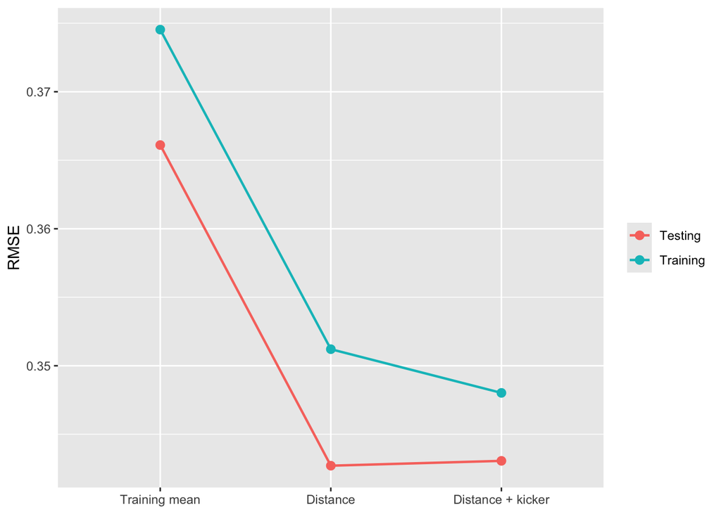

```r
ggplot(
  model_comparison,
  aes(x = model, y = rmse, color = sample, group = sample)
) +
  geom_line(linewidth = 0.8) +
  geom_point(size = 2.5) +
  labs(x = NULL, y = "RMSE", color = NULL)
```

The distance-only model has the lowest testing RMSE. Adding `kicker` lowers training RMSE but slightly raises testing RMSE, so the held-out results select the distance-only model.

Sports-data packages, plotting references, and project datasets are collected on the separate Project Resources page.